# ACA2-MC

## Analysis Challenge Assignment 2

### Author: Ming Chen

#### Introduction

I will set 4 sections to complete this assignment  
1.clean data  
2.find relationships (between independent variables and depend variable)  
3.build a classifier (by using the variables that are correlated with on/off-task behavior)  
4.evaluate the classifier

#### 1. Clean data

#### 1.1 Import data

```python
import os
os.chdir('D:\\Learning\\CU\\Courses\\EDM\\ACA2\\aca2_dataset')
os.getcwd()
```

```
'D:\\Learning\\CU\\Courses\\EDM\\ACA2\\aca2_dataset'
```

```python
import numpy as np
import pandas as pd
```

```python
TrainData=pd.read_csv("aca2_dataset_training.csv")
ValiData=pd.read_csv("aca2_dataset_validation.csv")
TrainData
```

|  | UNIQUEID | SCHOOL | Class | GRADE | CODER | STUDENTID | Gender | OBSNUM | totalobs-forsession | Activity | ONTASK | TRANSITIONS | NumACTIVITIES | FORMATchanges | NumFORMATS | Obsv/act | Transitions/Durations | Total Time |
| --- | --- | --- | --- | --- | --- | --- | --- | --- | --- | --- | --- | --- | --- | --- | --- | --- | --- | --- |
| 0 | 34880 | A | T8T | 2 | Z | 965160 | 1 | 12 | 224 | Wholecarpet | Y | 1 | 2 | 1 | 2 | 1390.500000 | 0.000664 | 1027 |
| 1 | 32344 | B | T9U | 3 | Z | 11665 | 1 | 11 | 225 | Individual | Y | 2 | 3 | 2 | 3 | 890.333333 | 0.002545 | 213 |
| 2 | 14774 | B | T9Q | 0 | Z | 187441 | 0 | 21 | 374 | Smallgroup | Y | 3 | 4 | 1 | 2 | 770.500000 | 0.001439 | 2078 |
| 3 | 19468 | A | T8S | 1 | Z | 402837 | 0 | 17 | 320 | Wholedesks | Y | 5 | 6 | 0 | 1 | 592.333333 | 0.001407 | 3229 |
| 4 | 31570 | B | T9T | 2 | Z | 300647 | 1 | 2 | 35 | Wholedesks | Y | 2 | 3 | 1 | 2 | 870.000000 | 0.005882 | 260 |
| ... | ... | ... | ... | ... | ... | ... | ... | ... | ... | ... | ... | ... | ... | ... | ... | ... | ... | ... |
| 22179 | 30762 | B | T9Q | 0 | Z | 749212 | 1 | 5 | 95 | Wholecarpet | Y | 2 | 3 | 2 | 3 | 969.000000 | 0.002959 | 652 |
| 22180 | 14611 | B | T9Q | 0 | Z | 87701 | 0 | 12 | 211 | Smallgroup | N | 3 | 4 | 1 | 2 | 770.500000 | 0.001439 | 708 |
| 22181 | 20432 | A | T8VQ | 4 | Z | 130859 | 0 | 6 | 95 | Smallgroup | N | 1 | 2 | 0 | 1 | 1060.000000 | 0.000472 | 362 |
| 22182 | 38264 | E | T6Q | 0 | Y | 874565 | 1 | 10 | 147 | Wholedesks | Y | 1 | 2 | 1 | 2 | 1204.500000 | 0.000838 | 60 |
| 22183 | 21734 | A | T8R | 4 | Z | 468563 | 0 | 3 | 49 | Wholedesks | Y | 0 | 1 | 0 | 1 | 2076.000000 | 0.000000 | 803 |

22184 rows × 18 columns

#### 1.2 describe data

```python
# To get a overview of the data and check the type of the data
TrainData.describe(include='all')
```

|  | UNIQUEID | SCHOOL | Class | GRADE | CODER | STUDENTID | Gender | OBSNUM | totalobs-forsession | Activity | ONTASK | TRANSITIONS | NumACTIVITIES | FORMATchanges | NumFORMATS | Obsv/act | Transitions/Durations | Total Time |
| --- | --- | --- | --- | --- | --- | --- | --- | --- | --- | --- | --- | --- | --- | --- | --- | --- | --- | --- |
| count | 22184.000000 | 22184 | 22184 | 22184.000000 | 22184 | 22184.000000 | 22184.000000 | 22184.000000 | 22184.000000 | 22184 | 22184 | 22184.000000 | 22184.000000 | 22184.000000 | 22184.000000 | 22184.000000 | 22184.000000 | 22184.000000 |
| unique | NaN | 5 | 22 | NaN | 2 | NaN | NaN | NaN | NaN | 6 | 2 | NaN | NaN | NaN | NaN | NaN | NaN | NaN |
| top | NaN | A | T8S | NaN | Z | NaN | NaN | NaN | NaN | Wholedesks | Y | NaN | NaN | NaN | NaN | NaN | NaN | NaN |
| freq | NaN | 5477 | 1310 | NaN | 21214 | NaN | NaN | NaN | NaN | 7144 | 14938 | NaN | NaN | NaN | NaN | NaN | NaN | NaN |
| mean | 28256.558556 | NaN | NaN | 2.056076 | NaN | 506965.948521 | 0.506446 | 9.621168 | 170.693608 | NaN | NaN | 2.383114 | 3.383114 | 1.534304 | 2.534304 | 973.525214 | 0.003159 | 774.587811 |
| std | 8030.006461 | NaN | NaN | 1.503220 | NaN | 283257.429497 | 0.499970 | 5.702232 | 105.788938 | NaN | NaN | 1.315163 | 1.315163 | 1.229399 | 1.229399 | 454.538354 | 0.010309 | 665.169774 |
| min | 14400.000000 | NaN | NaN | 0.000000 | NaN | 1123.000000 | 0.000000 | 1.000000 | 1.000000 | NaN | NaN | 0.000000 | 1.000000 | 0.000000 | 1.000000 | 387.000000 | 0.000000 | 0.000000 |
| 25% | 21276.750000 | NaN | NaN | 1.000000 | NaN | 264220.000000 | 0.000000 | 5.000000 | 82.000000 | NaN | NaN | 1.000000 | 2.000000 | 1.000000 | 2.000000 | 721.200000 | 0.000839 | 252.000000 |
| 50% | 28263.500000 | NaN | NaN | 2.000000 | NaN | 514301.000000 | 1.000000 | 9.000000 | 165.000000 | NaN | NaN | 2.000000 | 3.000000 | 1.000000 | 2.000000 | 876.250000 | 0.001513 | 586.500000 |
| 75% | 35231.250000 | NaN | NaN | 4.000000 | NaN | 743450.000000 | 1.000000 | 14.000000 | 248.000000 | NaN | NaN | 3.000000 | 4.000000 | 2.000000 | 3.000000 | 1106.750000 | 0.003268 | 1121.000000 |
| max | 42130.000000 | NaN | NaN | 4.000000 | NaN | 999979.000000 | 1.000000 | 32.000000 | 511.000000 | NaN | NaN | 6.000000 | 7.000000 | 5.000000 | 6.000000 | 2735.000000 | 0.666667 | 3554.000000 |

```python
# check if there is any missing data
print(TrainData.isnull().sum())
print(ValiData.isnull().sum())
```

```
UNIQUEID                 0
SCHOOL                   0
Class                    0
GRADE                    0
CODER                    0
STUDENTID                0
Gender                   0
OBSNUM                   0
totalobs-forsession      0
Activity                 0
ONTASK                   0
TRANSITIONS              0
NumACTIVITIES            0
FORMATchanges            0
NumFORMATS               0
Obsv/act                 0
Transitions/Durations    0
Total Time               0
dtype: int64
UNIQUEID                 0
SCHOOL                   0
Class                    0
GRADE                    0
CODER                    0
STUDENTID                0
Gender                   0
OBSNUM                   0
totalobs-forsession      0
Activity                 0
ONTASK                   0
TRANSITIONS              0
NumACTIVITIES            0
FORMATchanges            0
NumFORMATS               0
Obsv/act                 0
Transitions/Durations    0
Total Time               0
dtype: int64
```

#### 1.3 select data

```python
# create a new dataset that can include only the columns that may be used to build the classifier
# Remove: uniqueid,school,obsnum,class,studentid,coder,totalobs-forsession (Theses are used to mark the observation)
# Keep: grade, gender, activity, ontask, total time, NumActivity, transitions, Numformats, formatchanges,obsv/act, transition/duration (These data may be correlated with on/off task)
TraData=TrainData.drop(['UNIQUEID','SCHOOL','Class','STUDENTID','CODER','OBSNUM','totalobs-forsession'],axis=1)
TraData
```

|  | GRADE | Gender | Activity | ONTASK | TRANSITIONS | NumACTIVITIES | FORMATchanges | NumFORMATS | Obsv/act | Transitions/Durations | Total Time |
| --- | --- | --- | --- | --- | --- | --- | --- | --- | --- | --- | --- |
| 0 | 2 | 1 | Wholecarpet | Y | 1 | 2 | 1 | 2 | 1390.500000 | 0.000664 | 1027 |
| 1 | 3 | 1 | Individual | Y | 2 | 3 | 2 | 3 | 890.333333 | 0.002545 | 213 |
| 2 | 0 | 0 | Smallgroup | Y | 3 | 4 | 1 | 2 | 770.500000 | 0.001439 | 2078 |
| 3 | 1 | 0 | Wholedesks | Y | 5 | 6 | 0 | 1 | 592.333333 | 0.001407 | 3229 |
| 4 | 2 | 1 | Wholedesks | Y | 2 | 3 | 1 | 2 | 870.000000 | 0.005882 | 260 |
| ... | ... | ... | ... | ... | ... | ... | ... | ... | ... | ... | ... |
| 22179 | 0 | 1 | Wholecarpet | Y | 2 | 3 | 2 | 3 | 969.000000 | 0.002959 | 652 |
| 22180 | 0 | 0 | Smallgroup | N | 3 | 4 | 1 | 2 | 770.500000 | 0.001439 | 708 |
| 22181 | 4 | 0 | Smallgroup | N | 1 | 2 | 0 | 1 | 1060.000000 | 0.000472 | 362 |
| 22182 | 0 | 1 | Wholedesks | Y | 1 | 2 | 1 | 2 | 1204.500000 | 0.000838 | 60 |
| 22183 | 4 | 0 | Wholedesks | Y | 0 | 1 | 0 | 1 | 2076.000000 | 0.000000 | 803 |

22184 rows × 11 columns

```python
# Because transitions=NumActivity-1, formatchanges=numformats-1, only select one of them to simplify the datasets
TrData=TraData.drop(['NumACTIVITIES','NumFORMATS'],axis=1)
TrData
```

|  | GRADE | Gender | Activity | ONTASK | TRANSITIONS | FORMATchanges | Obsv/act | Transitions/Durations | Total Time |
| --- | --- | --- | --- | --- | --- | --- | --- | --- | --- |
| 0 | 2 | 1 | Wholecarpet | Y | 1 | 1 | 1390.500000 | 0.000664 | 1027 |
| 1 | 3 | 1 | Individual | Y | 2 | 2 | 890.333333 | 0.002545 | 213 |
| 2 | 0 | 0 | Smallgroup | Y | 3 | 1 | 770.500000 | 0.001439 | 2078 |
| 3 | 1 | 0 | Wholedesks | Y | 5 | 0 | 592.333333 | 0.001407 | 3229 |
| 4 | 2 | 1 | Wholedesks | Y | 2 | 1 | 870.000000 | 0.005882 | 260 |
| ... | ... | ... | ... | ... | ... | ... | ... | ... | ... |
| 22179 | 0 | 1 | Wholecarpet | Y | 2 | 2 | 969.000000 | 0.002959 | 652 |
| 22180 | 0 | 0 | Smallgroup | N | 3 | 1 | 770.500000 | 0.001439 | 708 |
| 22181 | 4 | 0 | Smallgroup | N | 1 | 0 | 1060.000000 | 0.000472 | 362 |
| 22182 | 0 | 1 | Wholedesks | Y | 1 | 1 | 1204.500000 | 0.000838 | 60 |
| 22183 | 4 | 0 | Wholedesks | Y | 0 | 0 | 2076.000000 | 0.000000 | 803 |

22184 rows × 9 columns

```python
## drop the data over or below two standarad deviation (deleted because it makes little sense, and has a bad effect to the result.)
#mta=TrData['Transitions/Durations'].mean()
#sta=TrData['Transitions/Durations'].std()
#taup=mta+2*sta
#tadown=mta-2*sta
#TrData=TrData[TrData['Transitions/Durations']<taup]
#TrData=TrData[TrData['Transitions/Durations']>tadown]

#mtt=TrData['Total Time'].mean()
#stt=TrData['Total Time'].std()
#ttup=mtt+2*stt
#ttdown=mtt-2*stt
#TrData=TrData[TrData['Total Time']<ttup]
#TrData=TrData[TrData['Total Time']>ttdown]

#TrData
```

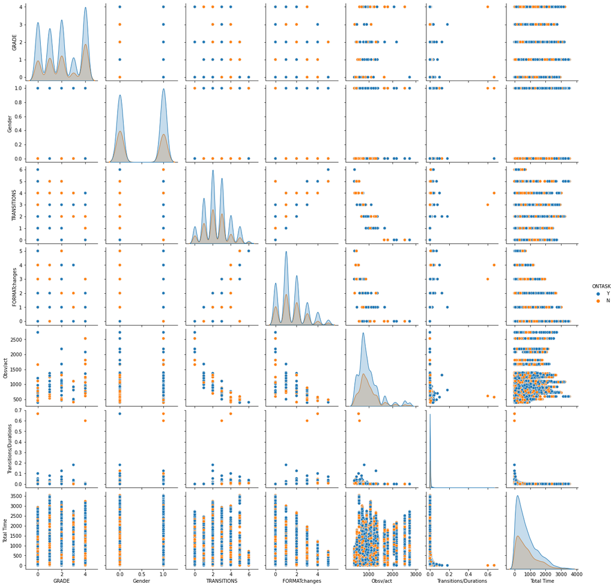

```python
import seaborn as sns
sns.pairplot(TrData,hue="ONTASK")
```

```python
# Do the same for validation dataset
ValData=ValiData.drop(['UNIQUEID','SCHOOL','Class','STUDENTID','CODER','OBSNUM','totalobs-forsession'],axis=1)
VaData=ValData.drop(['NumACTIVITIES','NumFORMATS'],axis=1)
VaData
```

|  | GRADE | Gender | Activity | ONTASK | TRANSITIONS | FORMATchanges | Obsv/act | Transitions/Durations | Total Time |
| --- | --- | --- | --- | --- | --- | --- | --- | --- | --- |
| 0 | 4 | 0 | Wholecarpet | Y | 1 | 1 | 1677.00 | 0.000446 | 0 |
| 1 | 1 | 0 | Wholedesks | Y | 3 | 3 | 826.00 | 0.003672 | 0 |
| 2 | 4 | 1 | Wholecarpet | Y | 3 | 2 | 862.75 | 0.004658 | 0 |
| 3 | 2 | 0 | Wholecarpet | N | 2 | 0 | 1073.00 | 0.000621 | 0 |
| 4 | 1 | 0 | Individual | Y | 3 | 2 | 1106.75 | 0.002841 | 0 |
| ... | ... | ... | ... | ... | ... | ... | ... | ... | ... |
| 5542 | 4 | 0 | Testing | Y | 0 | 0 | 2530.00 | 0.000000 | 2367 |
| 5543 | 4 | 1 | Testing | Y | 0 | 0 | 2530.00 | 0.000000 | 2375 |
| 5544 | 4 | 1 | Testing | N | 0 | 0 | 2530.00 | 0.000000 | 2389 |
| 5545 | 4 | 1 | Testing | Y | 0 | 0 | 2530.00 | 0.000000 | 2522 |
| 5546 | 4 | 1 | Testing | Y | 0 | 0 | 2530.00 | 0.000000 | 2525 |

5547 rows × 9 columns

#### 1.4 Transform data

```python
# recode the column 'Activity' and 'Ontask'
Adummy=pd.get_dummies(TrData['Activity'])
Odummy=pd.get_dummies(TrData['ONTASK'],prefix='ontask')
TData=pd.concat([TrData,Adummy,Odummy],axis=1)
TData=TData.drop(['ONTASK','ontask_N','Activity'],axis=1)
```

```python
# Do the same for validation data
Cdummy=pd.get_dummies(VaData['Activity'])
Ndummy=pd.get_dummies(VaData['ONTASK'],prefix='ontask')
VData=pd.concat([VaData,Cdummy,Ndummy],axis=1)
VData=VData.drop(['ONTASK','ontask_N','Activity'],axis=1)
VData
```

|  | GRADE | Gender | TRANSITIONS | FORMATchanges | Obsv/act | Transitions/Durations | Total Time | Dancing | Individual | Smallgroup | Testing | Wholecarpet | Wholedesks | ontask_Y |
| --- | --- | --- | --- | --- | --- | --- | --- | --- | --- | --- | --- | --- | --- | --- |
| 0 | 4 | 0 | 1 | 1 | 1677.00 | 0.000446 | 0 | 0 | 0 | 0 | 0 | 1 | 0 | 1 |
| 1 | 1 | 0 | 3 | 3 | 826.00 | 0.003672 | 0 | 0 | 0 | 0 | 0 | 0 | 1 | 1 |
| 2 | 4 | 1 | 3 | 2 | 862.75 | 0.004658 | 0 | 0 | 0 | 0 | 0 | 1 | 0 | 1 |
| 3 | 2 | 0 | 2 | 0 | 1073.00 | 0.000621 | 0 | 0 | 0 | 0 | 0 | 1 | 0 | 0 |
| 4 | 1 | 0 | 3 | 2 | 1106.75 | 0.002841 | 0 | 0 | 1 | 0 | 0 | 0 | 0 | 1 |
| ... | ... | ... | ... | ... | ... | ... | ... | ... | ... | ... | ... | ... | ... | ... |
| 5542 | 4 | 0 | 0 | 0 | 2530.00 | 0.000000 | 2367 | 0 | 0 | 0 | 1 | 0 | 0 | 1 |
| 5543 | 4 | 1 | 0 | 0 | 2530.00 | 0.000000 | 2375 | 0 | 0 | 0 | 1 | 0 | 0 | 1 |
| 5544 | 4 | 1 | 0 | 0 | 2530.00 | 0.000000 | 2389 | 0 | 0 | 0 | 1 | 0 | 0 | 0 |
| 5545 | 4 | 1 | 0 | 0 | 2530.00 | 0.000000 | 2522 | 0 | 0 | 0 | 1 | 0 | 0 | 1 |
| 5546 | 4 | 1 | 0 | 0 | 2530.00 | 0.000000 | 2525 | 0 | 0 | 0 | 1 | 0 | 0 | 1 |

5547 rows × 14 columns

#### 2. Find relationships

```python
print(TData.corr())
```

```
                          GRADE    Gender  TRANSITIONS  FORMATchanges  \
GRADE                  1.000000 -0.021774    -0.200491      -0.230749
Gender                -0.021774  1.000000    -0.037932       0.005727
TRANSITIONS           -0.200491 -0.037932     1.000000       0.657793
FORMATchanges         -0.230749  0.005727     0.657793       1.000000
Obsv/act               0.163693  0.024606    -0.803050      -0.540569
Transitions/Durations -0.080145 -0.004901     0.254934       0.304876
Total Time             0.106143 -0.008385    -0.154998      -0.454299
Dancing               -0.097113 -0.006540     0.110817       0.118705
Individual            -0.062919  0.001716    -0.052504       0.137326
Smallgroup             0.164350 -0.003160     0.047551      -0.114331
Testing                0.178335  0.028869    -0.249888      -0.172107
Wholecarpet           -0.430354  0.024270    -0.000539       0.096464
Wholedesks             0.279332 -0.028761     0.060741      -0.080127
ontask_Y              -0.049279  0.045508     0.032307       0.005752

                       Obsv/act  Transitions/Durations  Total Time   Dancing  \
GRADE                  0.163693              -0.080145    0.106143 -0.097113
Gender                 0.024606              -0.004901   -0.008385 -0.006540
TRANSITIONS           -0.803050               0.254934   -0.154998  0.110817
FORMATchanges         -0.540569               0.304876   -0.454299  0.118705
Obsv/act               1.000000              -0.196615    0.229982 -0.081473
Transitions/Durations -0.196615               1.000000   -0.180762  0.237021
Total Time             0.229982              -0.180762    1.000000 -0.077024
Dancing               -0.081473               0.237021   -0.077024  1.000000
Individual             0.019864              -0.000775   -0.116708 -0.036977
Smallgroup            -0.070567              -0.016945    0.089460 -0.035838
Testing                0.472229              -0.042261    0.119864 -0.010041
Wholecarpet            0.012652              -0.000856   -0.040467 -0.042490
Wholedesks            -0.093253              -0.008666    0.039904 -0.050184
ontask_Y              -0.007042              -0.002502   -0.002905  0.016211

                       Individual  Smallgroup   Testing  Wholecarpet  \
GRADE                   -0.062919    0.164350  0.178335    -0.430354
Gender                   0.001716   -0.003160  0.028869     0.024270
TRANSITIONS             -0.052504    0.047551 -0.249888    -0.000539
FORMATchanges            0.137326   -0.114331 -0.172107     0.096464
Obsv/act                 0.019864   -0.070567  0.472229     0.012652
Transitions/Durations   -0.000775   -0.016945 -0.042261    -0.000856
Total Time              -0.116708    0.089460  0.119864    -0.040467
```

[output cut: 8 more lines]

```
                       Wholedesks  ontask_Y
GRADE                    0.279332 -0.049279
Gender                  -0.028761  0.045508
TRANSITIONS              0.060741  0.032307
FORMATchanges           -0.080127  0.005752
Obsv/act                -0.093253 -0.007042
Transitions/Durations   -0.008666 -0.002502
Total Time               0.039904 -0.002905
Dancing                 -0.050184  0.016211
Individual              -0.349991 -0.019875
Smallgroup              -0.339214  0.037120
Testing                 -0.095042  0.025729
Wholecarpet             -0.402168  0.016907
Wholedesks               1.000000 -0.040019
ontask_Y                -0.040019  1.000000
```

```python
# Drop these weak correlations (<0.01)
TXs=TData.drop(['ontask_Y','FORMATchanges','Obsv/act','Transitions/Durations','Total Time'],axis=1)
TY=TData.loc[:,"ontask_Y"].values.reshape(-1,1)
TXs
```

|  | GRADE | Gender | TRANSITIONS | Dancing | Individual | Smallgroup | Testing | Wholecarpet | Wholedesks |
| --- | --- | --- | --- | --- | --- | --- | --- | --- | --- |
| 0 | 2 | 1 | 1 | 0 | 0 | 0 | 0 | 1 | 0 |
| 1 | 3 | 1 | 2 | 0 | 1 | 0 | 0 | 0 | 0 |
| 2 | 0 | 0 | 3 | 0 | 0 | 1 | 0 | 0 | 0 |
| 3 | 1 | 0 | 5 | 0 | 0 | 0 | 0 | 0 | 1 |
| 4 | 2 | 1 | 2 | 0 | 0 | 0 | 0 | 0 | 1 |
| ... | ... | ... | ... | ... | ... | ... | ... | ... | ... |
| 22179 | 0 | 1 | 2 | 0 | 0 | 0 | 0 | 1 | 0 |
| 22180 | 0 | 0 | 3 | 0 | 0 | 1 | 0 | 0 | 0 |
| 22181 | 4 | 0 | 1 | 0 | 0 | 1 | 0 | 0 | 0 |
| 22182 | 0 | 1 | 1 | 0 | 0 | 0 | 0 | 0 | 1 |
| 22183 | 4 | 0 | 0 | 0 | 0 | 0 | 0 | 0 | 1 |

22184 rows × 9 columns

#### 3. Build classifier

```python
# Use Decision Tree to build the classifier

from sklearn.tree import DecisionTreeClassifier
OntaskTreeModel=DecisionTreeClassifier()
OntaskTreeModel.fit(TXs,TY)
```

```
DecisionTreeClassifier()
```

```python
from sklearn import tree
text_representation=tree.export_text(OntaskTreeModel)
print(text_representation)
```

```
|--- feature_0 <= 3.50
|   |--- feature_5 <= 0.50
|   |   |--- feature_1 <= 0.50
|   |   |   |--- feature_0 <= 0.50
|   |   |   |   |--- feature_3 <= 0.50
|   |   |   |   |   |--- feature_2 <= 5.50
|   |   |   |   |   |   |--- feature_2 <= 3.50
|   |   |   |   |   |   |   |--- feature_2 <= 2.50
|   |   |   |   |   |   |   |   |--- feature_2 <= 1.50
|   |   |   |   |   |   |   |   |   |--- feature_7 <= 0.50
|   |   |   |   |   |   |   |   |   |   |--- class: 1
|   |   |   |   |   |   |   |   |   |--- feature_7 >  0.50
|   |   |   |   |   |   |   |   |   |   |--- feature_2 <= 0.50
|   |   |   |   |   |   |   |   |   |   |   |--- class: 1
|   |   |   |   |   |   |   |   |   |   |--- feature_2 >  0.50
|   |   |   |   |   |   |   |   |   |   |   |--- class: 1
|   |   |   |   |   |   |   |   |--- feature_2 >  1.50
|   |   |   |   |   |   |   |   |   |--- feature_7 <= 0.50
|   |   |   |   |   |   |   |   |   |   |--- class: 1
|   |   |   |   |   |   |   |   |   |--- feature_7 >  0.50
|   |   |   |   |   |   |   |   |   |   |--- class: 1
|   |   |   |   |   |   |   |--- feature_2 >  2.50
|   |   |   |   |   |   |   |   |--- feature_8 <= 0.50
|   |   |   |   |   |   |   |   |   |--- feature_4 <= 0.50
|   |   |   |   |   |   |   |   |   |   |--- class: 1
|   |   |   |   |   |   |   |   |   |--- feature_4 >  0.50
|   |   |   |   |   |   |   |   |   |   |--- class: 1
|   |   |   |   |   |   |   |   |--- feature_8 >  0.50
|   |   |   |   |   |   |   |   |   |--- class: 1
|   |   |   |   |   |   |--- feature_2 >  3.50
|   |   |   |   |   |   |   |--- feature_2 <= 4.50
|   |   |   |   |   |   |   |   |--- feature_7 <= 0.50
|   |   |   |   |   |   |   |   |   |--- class: 1
|   |   |   |   |   |   |   |   |--- feature_7 >  0.50
|   |   |   |   |   |   |   |   |   |--- class: 1
|   |   |   |   |   |   |   |--- feature_2 >  4.50
|   |   |   |   |   |   |   |   |--- feature_8 <= 0.50
|   |   |   |   |   |   |   |   |   |--- class: 1
|   |   |   |   |   |   |   |   |--- feature_8 >  0.50
|   |   |   |   |   |   |   |   |   |--- class: 1
```

[output cut: 396 more lines]

```
|   |   |   |   |   |--- feature_1 >  0.50
|   |   |   |   |   |   |--- feature_2 <= 1.50
|   |   |   |   |   |   |   |--- class: 1
|   |   |   |   |   |   |--- feature_2 >  1.50
|   |   |   |   |   |   |   |--- class: 1
|   |   |   |--- feature_2 >  2.50
|   |   |   |   |--- feature_1 <= 0.50
|   |   |   |   |   |--- class: 1
|   |   |   |   |--- feature_1 >  0.50
|   |   |   |   |   |--- class: 1
|   |   |--- feature_2 >  3.50
|   |   |   |--- feature_1 <= 0.50
|   |   |   |   |--- class: 1
|   |   |   |--- feature_1 >  0.50
|   |   |   |   |--- class: 1
```

#### 4. Evaluate model

```python
# Select validation data from VData according to the classifier
VXs=VData.drop(['ontask_Y','FORMATchanges','Obsv/act','Transitions/Durations','Total Time'],axis=1)
VY=VData.loc[:,"ontask_Y"].values.reshape(-1,1)
VXs
```

|  | GRADE | Gender | TRANSITIONS | Dancing | Individual | Smallgroup | Testing | Wholecarpet | Wholedesks |
| --- | --- | --- | --- | --- | --- | --- | --- | --- | --- |
| 0 | 4 | 0 | 1 | 0 | 0 | 0 | 0 | 1 | 0 |
| 1 | 1 | 0 | 3 | 0 | 0 | 0 | 0 | 0 | 1 |
| 2 | 4 | 1 | 3 | 0 | 0 | 0 | 0 | 1 | 0 |
| 3 | 2 | 0 | 2 | 0 | 0 | 0 | 0 | 1 | 0 |
| 4 | 1 | 0 | 3 | 0 | 1 | 0 | 0 | 0 | 0 |
| ... | ... | ... | ... | ... | ... | ... | ... | ... | ... |
| 5542 | 4 | 0 | 0 | 0 | 0 | 0 | 1 | 0 | 0 |
| 5543 | 4 | 1 | 0 | 0 | 0 | 0 | 1 | 0 | 0 |
| 5544 | 4 | 1 | 0 | 0 | 0 | 0 | 1 | 0 | 0 |
| 5545 | 4 | 1 | 0 | 0 | 0 | 0 | 1 | 0 | 0 |
| 5546 | 4 | 1 | 0 | 0 | 0 | 0 | 1 | 0 | 0 |

5547 rows × 9 columns

```python
# Get the predicted value
PY=OntaskTreeModel.predict(VXs)
PY
```

```
array([1, 1, 1, ..., 1, 1, 1], dtype=uint8)
```

```python
# confusion matrix
from sklearn.metrics import confusion_matrix
print(confusion_matrix(VY,PY))
```

```
[[ 105 1744]
 [  95 3603]]
```

```python
# obtaining accuracy score
from sklearn.metrics import accuracy_score
ac=accuracy_score(VY,PY)
print("The accuracy for this classifier is", ac*100, "%")
```

```
The accuracy for this classifier is 66.84694429421309 %
```

#### Interpretation

The classifier in the end can hardly predict the correct value.  
One possible explanation for the result is that there is no clear relationship between observation variables and on/task behaviors. The indication can be found from the correlation results. There are actually only weak correlations between independent variables and the dependent variable.  
I have tried to drop the strange values to clean the data in the dataset, but the result became even worse. I'm not sure where those values come from (maybe they make sense in the real case), so finally decided to keep them.  
I have dropped 'FORMATchanges','Obsv/act','Transitions/Durations','Total Time'after doing the correlations, which actually surprised me because I thought they would be important to on/off task behaviors. However, after dropping them, the prediction values seem to be better. It seems that the four variables have little effect on on/off task behaviors, what counts are the types of activity and the indivisual differences (age and gender) of children.